# Part II - Flights Insights

## by Mina Albert Ibrahim

## Investigation Overview

> - I get some results about average of Taxi out from airport in minutes,
> - percentage of top 10 times there are flights in 24 hours format,
> - also percentage of cancelled and devirted flights,
> - percentage of departure delayed flights(if delay time > 15 minutes),
> - relationship between time to be taxi out from the airport and time to be taxi in the airport

## Dataset Overview and Executive Summary

> - This dataset about all flights of USA from 1987 to 2022,
> - This dataset have great results like relationship between time to be taxi in the airport and time to be out from the airport
> - Also percentages of Devirted and cancelled flights
> - Top 10 times there are flights in it

## (Visualization 1)

> This visualization shows the percentage of top 10 times there are flights in it, We can see that, 00 is the most time there are flights in it with 67% from our data and other hours are almost equels to each other from 1987 and 2022

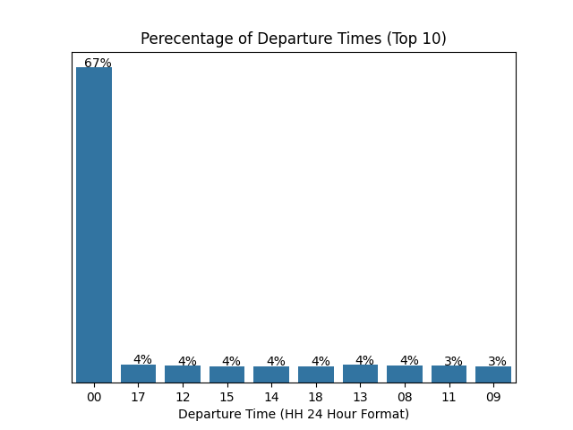

## (Visualization 2)

> This visualization, show percentage of cancelled flights we see only 2% are cancelled and 98% are not from 1987 and 2022

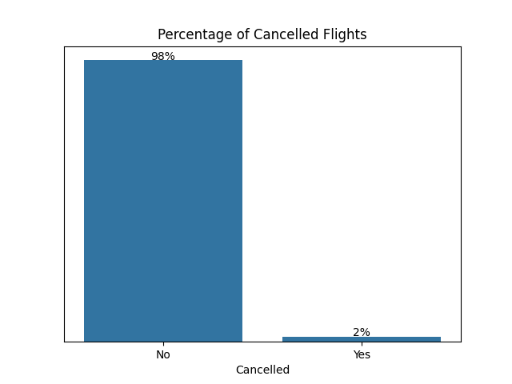

## (Visualization 3)

> This visualization, show percentage of devirted flights also we can see no any devirted flight from 1987 to 2022

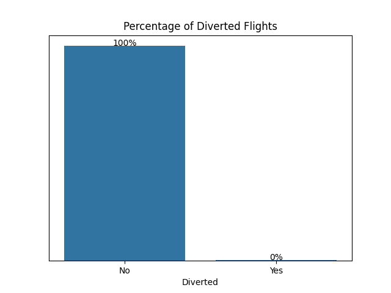